## Validation update - October 22, 2026

The revised R workflow executed and rendered. Before/after data contain 1,933/986 rows; complete-case model samples contain 1,910/981. All 30 flagged scenario prices were replaced in the hypothetical demonstration. Fitting R² changed from 0.8691 to 0.9213; this is not predictive validation or evidence of fraud. A ggfortify/na.exclude diagnostic mismatch was fixed with native lm diagnostic plots, and crowded facet axes were reformatted. Model formulas and the scenario assumptions were preserved.

# Housing Regression Diagnostics and Price Sensitivity

Cameron Batts

## Problem

Investigate repeated sale prices, model assumptions and sensitivity to model-based target replacement.

## Approach

Inspect the provided pre/post-2009 files, fit a fixed 15-term regression specification, compare diagnostic plots and retain raw targets separately from an optional replacement scenario.

## Limitations and corrections

Repeated prices, density peaks and residual patterns do not establish fraud. The original workflow replaced flagged targets with model predictions plus 1% noise; smoother residuals after that operation do not validate recovered prices or independent predictive accuracy. No held-out evaluation was reported. Existing images and PDF contain historical wording and interpretations that predate this correction.

## Verification

The revised R workflow was executed and rendered on October 22, 2026; see the validation record for current results and package versions.

```r
library(ggplot2)
read_prices <- function(path) {
  d <- read.csv(path, check.names = FALSE)
  d <- d[, !(names(d) %in% c("", "Id", "Utilities") | grepl("^Unnamed", names(d)))]
  for (v in c("MSSubClass", "OverallQual", "OverallCond")) d[[v]] <- factor(d[[v]])
  d
}
before <- read_prices("Data/PricesBefore2009.csv")
after <- read_prices("Data/PricesAfter2009.csv")
cat("Before rows:", nrow(before), "After rows:", nrow(after), "\n")
```

```
## Before rows: 1933 After rows: 986
```

```r
flagged <- which(after$SalePrice == 142769.7)
print(table(after$Neighborhood[flagged]))
```

```
##
## Blmngtn  BrDale Gilbert   NAmes NoRidge NPkVill NridgHt Somerst StoneBr
##       1       2       9       4       1       2       7       3       1
```

## Fit and inspect the observed data

```r
model_formula <- SalePrice ~ OverallQual + GrLivArea + GarageCars + GarageArea +
  TotalBsmtSF + FullBath + YearBuilt + YearRemodAdd + Fireplaces + LotArea +
  BsmtFinSF1 + KitchenQual + Neighborhood + ExterQual + X1stFlrSF
before_model <- lm(model_formula, data = before, na.action = na.exclude)
after_model <- lm(model_formula, data = after, na.action = na.exclude)
summary(before_model)
```

```
##
## Call:
## lm(formula = model_formula, data = before, na.action = na.exclude)
##
## Residuals:
##     Min      1Q  Median      3Q     Max
## -500606  -11301    1060   11433  209410
##
## Coefficients:
##                       Estimate Std. Error t value Pr(>|t|)
## (Intercept)         -9.286e+05  1.300e+05  -7.141 1.32e-12 ***
## OverallQual2        -5.738e+03  3.154e+04  -0.182 0.855647
## OverallQual3         1.040e+04  2.941e+04   0.354 0.723703
## OverallQual4         2.226e+04  2.930e+04   0.760 0.447537
## OverallQual5         2.944e+04  2.931e+04   1.004 0.315308
## OverallQual6         3.625e+04  2.936e+04   1.235 0.217074
## OverallQual7         4.837e+04  2.943e+04   1.643 0.100461
## OverallQual8         7.167e+04  2.957e+04   2.423 0.015478 *
## OverallQual9         9.991e+04  2.995e+04   3.336 0.000867 ***
## OverallQual10        1.453e+05  3.076e+04   4.723 2.50e-06 ***
## GrLivArea            4.257e+01  2.238e+00  19.021  < 2e-16 ***
## GarageCars           8.710e+03  2.078e+03   4.190 2.91e-05 ***
## GarageArea           8.002e+00  7.148e+00   1.120 0.263057
## TotalBsmtSF          5.077e+00  2.883e+00   1.761 0.078407 .
## FullBath             1.492e+02  1.825e+03   0.082 0.934877
## YearBuilt            2.502e+02  5.062e+01   4.943 8.40e-07 ***
## YearRemodAdd         2.464e+02  4.668e+01   5.278 1.46e-07 ***
## Fireplaces           7.716e+03  1.270e+03   6.078 1.48e-09 ***
## LotArea              4.237e-01  9.938e-02   4.263 2.12e-05 ***
## BsmtFinSF1           1.457e+01  1.788e+00   8.152 6.50e-16 ***
## KitchenQualFa       -2.481e+04  6.012e+03  -4.126 3.85e-05 ***
## KitchenQualGd       -2.356e+04  3.599e+03  -6.545 7.66e-11 ***
## KitchenQualTA       -2.650e+04  3.952e+03  -6.706 2.65e-11 ***
## NeighborhoodBlueste -2.440e+04  1.545e+04  -1.579 0.114407
## NeighborhoodBrDale  -2.125e+04  9.298e+03  -2.285 0.022414 *
## NeighborhoodBrkSide  6.000e+03  7.953e+03   0.754 0.450663
## NeighborhoodClearCr  1.345e+04  8.601e+03   1.564 0.117931
## NeighborhoodCollgCr  5.298e+03  6.731e+03   0.787 0.431293
## NeighborhoodCrawfor  2.618e+04  7.662e+03   3.418 0.000645 ***
## NeighborhoodEdwards -1.292e+04  7.347e+03  -1.758 0.078946 .
```

[output cut: 13 more lines]

```
## NeighborhoodStoneBr  3.892e+04  8.103e+03   4.803 1.69e-06 ***
## NeighborhoodSWISU    1.887e+03  9.097e+03   0.207 0.835658
## NeighborhoodTimber   1.110e+04  7.577e+03   1.466 0.142914
## NeighborhoodVeenker  2.919e+04  9.011e+03   3.239 0.001221 **
## ExterQualFa          1.023e+03  9.546e+03   0.107 0.914659
## ExterQualGd         -6.376e+03  5.145e+03  -1.239 0.215397
## ExterQualTA         -6.487e+03  5.618e+03  -1.155 0.248307
## X1stFlrSF            5.766e+00  3.327e+00   1.733 0.083238 .
## ---
## Signif. codes:  0 '***' 0.001 '**' 0.01 '*' 0.05 '.' 0.1 ' ' 1
##
## Residual standard error: 27640 on 1859 degrees of freedom
##   (23 observations deleted due to missingness)
## Multiple R-squared:  0.8833, Adjusted R-squared:  0.8801
## F-statistic: 281.3 on 50 and 1859 DF,  p-value: < 2.2e-16
```

```r
summary(after_model)
```

```
##
## Call:
## lm(formula = model_formula, data = after, na.action = na.exclude)
##
## Residuals:
##     Min      1Q  Median      3Q     Max
## -270665   -8685    1348   11161  205033
##
## Coefficients:
##                       Estimate Std. Error t value Pr(>|t|)
## (Intercept)         -1.098e+06  1.882e+05  -5.833 7.50e-09 ***
## OverallQual2        -2.503e+03  3.152e+04  -0.079 0.936715
## OverallQual3         1.108e+03  3.068e+04   0.036 0.971200
## OverallQual4         9.567e+03  2.999e+04   0.319 0.749778
## OverallQual5         1.418e+04  3.011e+04   0.471 0.637819
## OverallQual6         2.235e+04  3.019e+04   0.740 0.459310
## OverallQual7         3.211e+04  3.038e+04   1.057 0.290907
## OverallQual8         4.659e+04  3.060e+04   1.523 0.128159
## OverallQual9         6.809e+04  3.152e+04   2.160 0.030993 *
## OverallQual10        1.141e+05  3.325e+04   3.430 0.000629 ***
## GrLivArea            4.609e+01  3.335e+00  13.822  < 2e-16 ***
## GarageCars           3.140e+03  2.955e+03   1.062 0.288286
## GarageArea           1.906e+01  1.027e+01   1.856 0.063740 .
## TotalBsmtSF          1.857e+01  4.019e+00   4.622 4.34e-06 ***
## FullBath             1.890e+03  2.526e+03   0.748 0.454630
## YearBuilt            3.183e+02  7.503e+01   4.242 2.43e-05 ***
## YearRemodAdd         2.773e+02  6.573e+01   4.219 2.70e-05 ***
## Fireplaces           3.214e+03  1.764e+03   1.822 0.068822 .
## LotArea              8.393e-01  1.295e-01   6.482 1.47e-10 ***
## BsmtFinSF1           2.552e+01  2.536e+00  10.063  < 2e-16 ***
## KitchenQualFa       -2.892e+04  8.816e+03  -3.281 0.001074 **
## KitchenQualGd       -2.508e+04  5.746e+03  -4.364 1.42e-05 ***
## KitchenQualTA       -2.845e+04  6.210e+03  -4.582 5.23e-06 ***
## NeighborhoodBlueste -2.578e+03  1.577e+04  -0.163 0.870196
## NeighborhoodBrDale   1.149e+04  1.456e+04   0.789 0.430307
## NeighborhoodBrkSide  2.711e+04  1.248e+04   2.172 0.030108 *
## NeighborhoodClearCr  2.756e+04  1.345e+04   2.048 0.040797 *
## NeighborhoodCollgCr  1.582e+04  1.082e+04   1.462 0.144052
## NeighborhoodCrawfor  4.999e+04  1.219e+04   4.102 4.46e-05 ***
## NeighborhoodEdwards  9.523e+03  1.159e+04   0.822 0.411399
```

[output cut: 13 more lines]

```
## NeighborhoodStoneBr  5.216e+04  1.319e+04   3.955 8.23e-05 ***
## NeighborhoodSWISU    1.269e+04  1.324e+04   0.958 0.338271
## NeighborhoodTimber   1.701e+04  1.224e+04   1.390 0.164951
## NeighborhoodVeenker  3.652e+04  1.791e+04   2.039 0.041758 *
## ExterQualFa         -3.475e+04  1.147e+04  -3.030 0.002510 **
## ExterQualGd         -3.252e+04  7.601e+03  -4.279 2.07e-05 ***
## ExterQualTA         -3.656e+04  8.230e+03  -4.442 9.97e-06 ***
## X1stFlrSF           -1.233e+01  4.879e+00  -2.526 0.011692 *
## ---
## Signif. codes:  0 '***' 0.001 '**' 0.01 '*' 0.05 '.' 0.1 ' ' 1
##
## Residual standard error: 28230 on 930 degrees of freedom
##   (5 observations deleted due to missingness)
## Multiple R-squared:  0.8691, Adjusted R-squared:  0.8621
## F-statistic: 123.5 on 50 and 930 DF,  p-value: < 2.2e-16
```

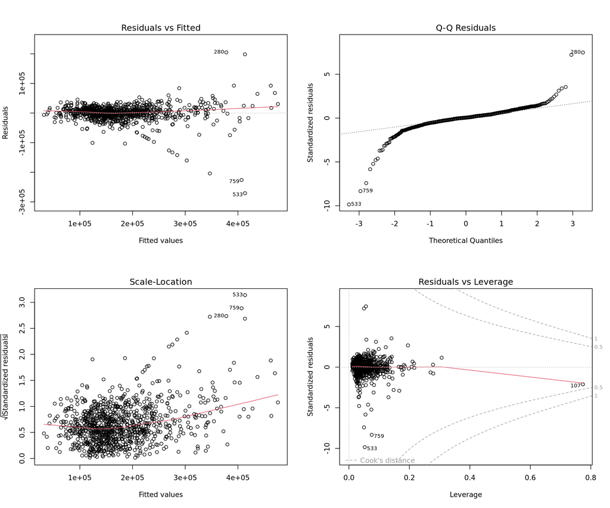

```r
old_par <- par(mfrow = c(2, 2))
plot(after_model)
```

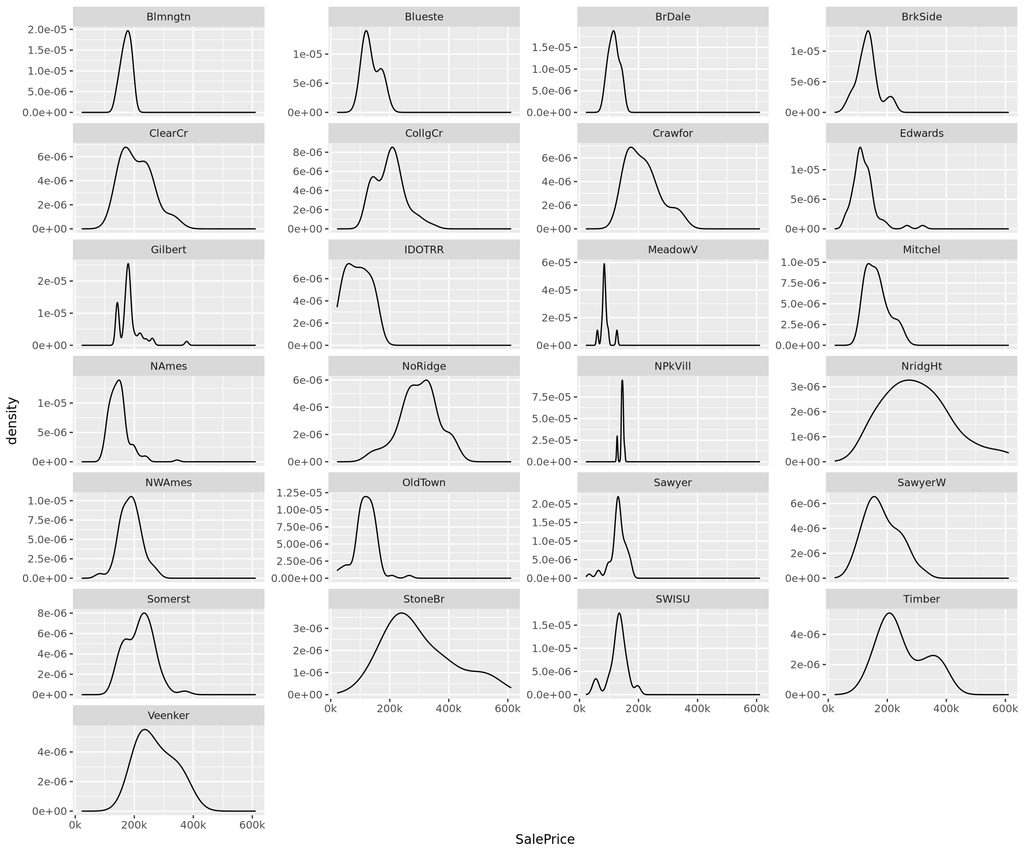

```r
par(old_par)
ggplot(after, aes(SalePrice)) + geom_density() + facet_wrap(~ Neighborhood, scales = "free_y", ncol = 4) +
  scale_x_continuous(breaks = function(limits) pretty(limits, n = 3),
                     labels = function(x) paste0(format(round(x / 1000), trim = TRUE), "k"))
```

## Optional scenario: model-based replacement

Repeated sale prices and residual patterns do not establish fraud. This scenario constructs alternative targets to examine sensitivity; it does not recover verified transaction values. Raw data remain untouched.

```r
# Align categorical levels to the training model; unknown levels become NA.
scenario_inputs <- after[flagged, , drop = FALSE]
for (v in names(before_model$xlevels)) {
  scenario_inputs[[v]] <- factor(scenario_inputs[[v]], levels = before_model$xlevels[[v]])
}
scenario_predictions <- predict(before_model, newdata = scenario_inputs)
replaceable <- which(is.finite(scenario_predictions) & scenario_predictions > 0)
set.seed(123)
scenario <- after
scenario$SalePrice[flagged[replaceable]] <- scenario_predictions[replaceable] +
  rnorm(length(replaceable), sd = 0.01 * scenario_predictions[replaceable])
cat("Scenario replacements:", length(replaceable), "of", length(flagged), "flagged rows\n")
```

```
## Scenario replacements: 30 of 30 flagged rows
```

```r
scenario_model <- lm(model_formula, data = scenario, na.action = na.exclude)
summary(scenario_model)
```

```
##
## Call:
## lm(formula = model_formula, data = scenario, na.action = na.exclude)
##
## Residuals:
##     Min      1Q  Median      3Q     Max
## -233665   -8608    1116    9633  176581
##
## Coefficients:
##                       Estimate Std. Error t value Pr(>|t|)
## (Intercept)         -1.150e+06  1.484e+05  -7.748 2.43e-14 ***
## OverallQual2        -9.491e+02  2.485e+04  -0.038 0.969544
## OverallQual3         9.839e+02  2.419e+04   0.041 0.967569
## OverallQual4         8.475e+03  2.364e+04   0.358 0.720105
## OverallQual5         1.383e+04  2.374e+04   0.583 0.560316
## OverallQual6         2.157e+04  2.381e+04   0.906 0.365087
## OverallQual7         2.986e+04  2.395e+04   1.247 0.212880
## OverallQual8         4.868e+04  2.412e+04   2.018 0.043872 *
## OverallQual9         7.301e+04  2.485e+04   2.938 0.003383 **
## OverallQual10        9.556e+04  2.621e+04   3.645 0.000282 ***
## GrLivArea            4.642e+01  2.629e+00  17.656  < 2e-16 ***
## GarageCars           5.149e+03  2.330e+03   2.210 0.027361 *
## GarageArea           1.386e+01  8.096e+00   1.712 0.087158 .
## TotalBsmtSF          2.250e+01  3.168e+00   7.103 2.43e-12 ***
## FullBath             4.300e+02  1.992e+03   0.216 0.829154
## YearBuilt            3.354e+02  5.916e+01   5.670 1.90e-08 ***
## YearRemodAdd         2.849e+02  5.182e+01   5.497 4.98e-08 ***
## Fireplaces           3.210e+03  1.391e+03   2.308 0.021239 *
## LotArea              8.904e-01  1.021e-01   8.722  < 2e-16 ***
## BsmtFinSF1           1.918e+01  1.999e+00   9.595  < 2e-16 ***
## KitchenQualFa       -3.124e+04  6.951e+03  -4.494 7.86e-06 ***
## KitchenQualGd       -2.635e+04  4.531e+03  -5.817 8.25e-09 ***
## KitchenQualTA       -3.073e+04  4.896e+03  -6.277 5.27e-10 ***
## NeighborhoodBlueste -3.634e+03  1.243e+04  -0.292 0.770137
## NeighborhoodBrDale   2.245e+03  1.148e+04   0.196 0.845028
## NeighborhoodBrkSide  2.695e+04  9.841e+03   2.738 0.006291 **
## NeighborhoodClearCr  2.724e+04  1.061e+04   2.568 0.010398 *
## NeighborhoodCollgCr  1.451e+04  8.529e+03   1.701 0.089189 .
## NeighborhoodCrawfor  4.961e+04  9.609e+03   5.162 2.98e-07 ***
## NeighborhoodEdwards  9.752e+03  9.136e+03   1.067 0.286067
```

[output cut: 13 more lines]

```
## NeighborhoodStoneBr  5.481e+04  1.040e+04   5.271 1.69e-07 ***
## NeighborhoodSWISU    1.368e+04  1.044e+04   1.310 0.190412
## NeighborhoodTimber   1.258e+04  9.652e+03   1.303 0.192782
## NeighborhoodVeenker  3.361e+04  1.412e+04   2.380 0.017536 *
## ExterQualFa         -3.202e+04  9.040e+03  -3.542 0.000416 ***
## ExterQualGd         -3.128e+04  5.993e+03  -5.219 2.22e-07 ***
## ExterQualTA         -3.383e+04  6.489e+03  -5.214 2.28e-07 ***
## X1stFlrSF           -9.857e+00  3.847e+00  -2.562 0.010550 *
## ---
## Signif. codes:  0 '***' 0.001 '**' 0.01 '*' 0.05 '.' 0.1 ' ' 1
##
## Residual standard error: 22250 on 930 degrees of freedom
##   (5 observations deleted due to missingness)
## Multiple R-squared:  0.9213, Adjusted R-squared:  0.9171
## F-statistic: 217.7 on 50 and 930 DF,  p-value: < 2.2e-16
```

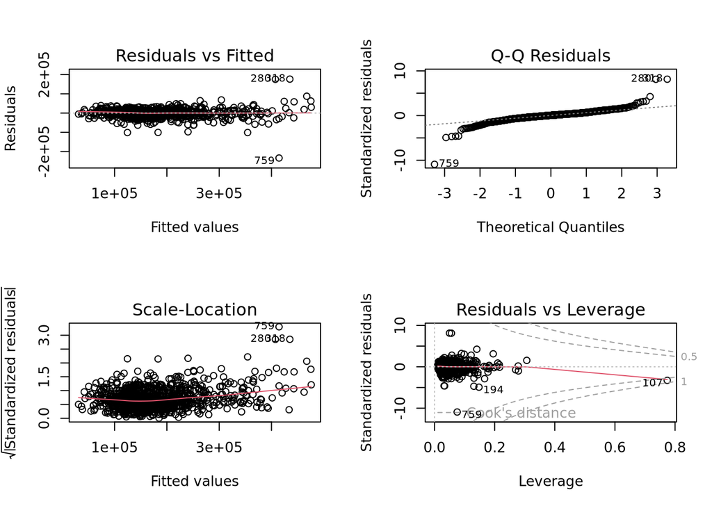

```r
old_par <- par(mfrow = c(2, 2))
plot(scenario_model)
```

```r
par(old_par)
```

Improved residuals after replacing targets with model predictions are partly expected by construction. They do not demonstrate improved prediction on independent, verified sales. Compare against held-out untouched transactions before making predictive claims. Complete-case fitting can change sample composition across periods.